# Problem Set 04

In a multi-armed bandit problem, the reward of different arms are assumed to be independent. In our simulated environment, the reward of each arm pull is sampled from a Gaussian distribution with unknown mean and known standard deviation, i.e., $ r_{i,t} \sim \mathcal N (\mu_i, \sigma^2) $, where $ i $ is arm index and $ t $ is the timestamp. The agent can only observe the index of each arm and the sample reward each time; and therefore, the learner should maintain sufficient statistics and construct reward estimator for each arm accordingly.

### Implement the explore-and-commit algorithm: The detailed procedure of this algorithm can be found below. The only hyper-paramater we need to choose is the length of the exploration phase (denoted as $ m $), whose theoretical value has also been discussed in the slides. Please implement this algorithm following steps discussed in class (Part A, 50 pts).

## Explore-Then-Commit Algorithm

This implementation follows the **Explore-Then-Commit** strategy for multi-armed bandits that we discussed in class. The objective is to minimize regret $R_T = T\mu^* - \mathbb{E}\left[\sum_{t=1}^T X_t\right]$, where $\mu^* = \max_i \mu_i$ is the highest true mean among all arms.

### Concepts from Slides & Framework

The ETC algorithm operates in two phases:

1. **Exploration Phase**: Each arm is pulled $m$ times, and empirical means $\hat\mu_i$ are computed.
2. **Commit Phase**: The arm with the highest empirical mean is chosen for all remaining rounds.

The regret decomposes into: $$ R_T \leq m \Delta + T \Delta \exp\left(-\frac{m\Delta^2}{4}\right) $$ where $\Delta = \mu^* - \mu_{(2)}$ is the gap between the best and second-best arm. This bound captures the trade-off between:

- **Exploration Regret** ($m \Delta$): Increases with $m$.
- **Exploitation Regret** ($T\Delta \exp(-m\Delta^2/4)$): Decreases with $m$.

To balance this trade-off, we use the theoretically motivated: $$ m = \left\lceil \frac{4}{\Delta^2} \log\left(\frac{T \Delta^2}{4}\right) \right\rceil $$ If $T\Delta^2 / 4 < 1$, we fall back to $m = \lfloor T / (2K) \rfloor$ to avoid taking the log of a value less than 1.

### Implementation Details

- For each $T$ and $K$, we generate a set of true means from $\text{Uniform}(0, 1)$.
- We compute $\Delta$ from the sorted true means (only well-defined for $K = 2$).
- During exploration, each arm is pulled $m$ times and empirical means $\hat\mu_i$ are computed.
- In the commit phase, the arm with the highest $\hat\mu_i$ is pulled for the remaining $T - mK$ rounds.
- We calculate:
  - Total reward accumulated.
  - Regret compared to the optimal arm.
  - The theoretical regret bound for comparison.

This approach is grounded in the assumption that the reward distributions are **$\sigma$-subgaussian**, allowing us to apply the exponential concentration bound that controls the probability of choosing a suboptimal arm.

### Limitations Acknowledged

- The value of $\Delta$ is unknown in practice and estimated using observed $\mu_i$.
- For $K > 2$, defining $\Delta$ becomes more complex and generalizing the regret bound requires pairwise gap considerations.
- The theoretical $m$ is optimal only under the idealized assumptions of the regret bound.

```python
import numpy as np
import math
import matplotlib.pyplot as plt
```

```python
def explore_then_commit(T, K, true_means, sigma):

    # Compute the gap Delta (suboptimality gap) between the best and second-best arm.
    # We do the second best to fulfill the \mu^* - \mu_i where the only i in the K = 2 case is \mu_2.
    sorted_means = np.sort(true_means)[::-1]
    Delta = sorted_means[0] - sorted_means[1]

    # Compute m using the formula from the slides.
    # But if T * Delta^2 / 4 < 1, the log becomes negative.
    # In that case, we set m to a fallback value.
    if (T * (Delta**2)) / 4 < 1:
        m = T // (2 * K)
    else:
        m = int(np.ceil((4 / (Delta**2)) * np.log((T * (Delta**2)) / 4)))

    # Ensure m is at least 1 and at most T/K.
    m = max(1, m)
    m = min(m, T // K)

    # Initialize lists to store rewards and chosen arms.
    rewards = []
    chosen_arms = []

    # Dict to store rewards for each arm during exploration.
    arm_rewards = {i: [] for i in range(K)}

    # ========== EXPLORATION PHASE ==========
    # Pull each arm m times.
    for i in range(K):
        for _ in range(m):
            reward = np.random.normal(true_means[i], sigma)
            arm_rewards[i].append(reward)
            rewards.append(reward)
            chosen_arms.append(i)

    # Compute the empirical means for each arm.
    empirical_means = np.array([np.mean(arm_rewards[i]) for i in range(K)])

    # Identify the best arm based on the empirical means.
    best_arm = np.argmax(empirical_means)

    # ========== COMMIT PHASE ==========
    remaining_rounds = T - (m * K)
    for _ in range(remaining_rounds):
        reward = np.random.normal(true_means[best_arm], sigma)
        rewards.append(reward)
        chosen_arms.append(best_arm)

    # ========== REGRET CALCULATION ==========
    best_true_mean = np.max(true_means)
    total_optimal_reward = best_true_mean * T
    total_reward = np.sum(rewards)
    regret = total_optimal_reward - total_reward

    # ========== THEORETICAL REGRET BOUND ==========
    theory_regret = m * Delta + T * Delta * np.exp(-m * (Delta**2) / 4)

    return {
        "total_reward": total_reward,
        "regret": regret,
        "theory_regret": theory_regret,
        "exploration_empirical_means": empirical_means,
        "chosen_best_arm": best_arm,
        "chosen_arms_history": chosen_arms,
        "rewards_history": rewards,
        "exploration_rounds_per_arm": m
    }

# ========== DEMONSTRATION ==========

T = 1000         # Total rounds
K = 2            # Number of arms (slides' theory is for K = 2)
sigma = 1.0      # Known standard deviation

# Generate random true means for each arm (unknown to the algorithm).
true_means = np.random.uniform(0, 1, size=K)

result = explore_then_commit(T, K, true_means, sigma)

print("\n========== Results Summary ==========")
print(f"True means of arms: {true_means.round(3)}\n")
print(f"Computed exploration rounds per arm (m): {result['exploration_rounds_per_arm']}\n")
print(f"Empirical means from exploration: {result['exploration_empirical_means'].round(3)}\n")
print(f"Chosen best arm (from exploration): {result['chosen_best_arm']}\n")
print(f"Total regret: {result['regret'].round(3)}\n")
print(f"Total regret theoretical upper bound: {result['theory_regret'].round(3)}")
```

```
========== Results Summary ==========
True means of arms: [0.785 0.741]

Computed exploration rounds per arm (m): 250

Empirical means from exploration: [0.853 0.673]

Chosen best arm (from exploration): 0

Total regret: 24.46

Total regret theoretical upper bound: 50.298
```

### Theoretical Upper Bound

So we have this theoretical upper bound of regret that we expect to see the empirical values to stay below this over multiple runs. To showcase this, the following code depicts that.

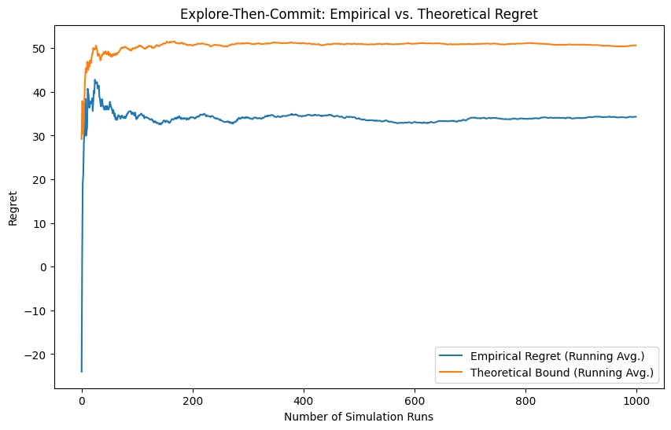

```
Final average empirical regret: 34.303
Final average theoretical bound: 50.634
```

```python
def run_multiple_simulations(T, K, sigma, num_runs=1000):
    """
    Runs the explore-then-commit simulation multiple times and plots
    the running average of empirical vs. theoretical regret.
    """
    empirical_regrets = []
    theoretical_regrets = []

    for _ in range(num_runs):

        # Generate new random means for each run
        true_means = np.random.uniform(0, 1, size=K)

        result = explore_then_commit(T, K, true_means, sigma)
        empirical_regrets.append(result["regret"])
        theoretical_regrets.append(result["theory_regret"])

    # Compute running averages
    cumulative_avg_empirical = np.cumsum(empirical_regrets) / np.arange(1, num_runs+1)
    cumulative_avg_theoretical = np.cumsum(theoretical_regrets) / np.arange(1, num_runs+1)

    # Plot
    plt.figure(figsize=(10, 6))
    plt.plot(cumulative_avg_empirical, label='Empirical Regret (Running Avg.)')
    plt.plot(cumulative_avg_theoretical, label='Theoretical Bound (Running Avg.)')
    plt.xlabel('Number of Simulation Runs')
    plt.ylabel('Regret')
    plt.title('Explore-Then-Commit: Empirical vs. Theoretical Regret')
    plt.legend()
    plt.show()

    # Return the final averages if you want them
    return cumulative_avg_empirical[-1], cumulative_avg_theoretical[-1]

# ========== DEMONSTRATION ==========

T = 1000
K = 2
sigma = 1.0
num_runs = 1000

final_empirical_avg, final_theoretical_avg = run_multiple_simulations(T, K, sigma, num_runs)
print(f"Final average empirical regret: {final_empirical_avg:.3f}")
print(f"Final average theoretical bound: {final_theoretical_avg:.3f}")
```

### Vary the total number of rounds $ T $ in the range $ [1000, 5000] $ with step size 1000, vary the number of arms $ K $ in the range of $ [10, 30] $ with step size 5, and repeat each experiment 5 times. Report your algorithm's regret (mean and standard deviation) under the theoretical hyper-parameter setting of $ m $ (Part B, 30 pts).

```python
def run_experiments():

    # Vary the total number of rounds T in [1000, 5000] (step 1000),
    # vary the number of arms K in [10, 30] (step 5),
    # repeat each experiment 5 times.

    # Report the mean and std of realized regret (and also theoretical regret) across these 5 runs.

    # Define the ranges for T and K
    T_values = [1000, 2000, 3000, 4000, 5000]
    K_values = [10, 15, 20, 25, 30]

    # For each combination, we'll store regrets across 5 runs
    results = []

    for T in T_values:
        for K in K_values:
            empirical_regrets = []

            # Repeat 5 times
            for _ in range(5):
                # Generate random true means
                true_means = np.random.uniform(0, 1, size=K)

                # Run the ETC algorithm
                outcome = explore_then_commit(T, K, true_means, sigma=1.0)

                empirical_regrets.append(outcome["regret"])

            # Compute mean and std
            mean_emp_reg = np.mean(empirical_regrets)
            std_emp_reg = np.std(empirical_regrets)

            results.append({
                "T": T,
                "K": K,
                "mean_empirical_regret": mean_emp_reg,
                "std_empirical_regret": std_emp_reg,
            })

    print("\n================ EXPERIMENT RESULTS ================")
    for r in results:
        print(f"T: {r["T"]},\n K: {r['K']},\n mean_regret: {r['mean_empirical_regret'].round(3)},\n std_regret: {r['std_empirical_regret'].round(3)}\n")
        print(f"================================")

run_experiments()
```

```
================ EXPERIMENT RESULTS ================
T: 1000,
 K: 10,
 mean_regret: 258.308,
 std_regret: 116.953

================================
T: 1000,
 K: 15,
 mean_regret: 497.951,
 std_regret: 31.592

================================
T: 1000,
 K: 20,
 mean_regret: 262.897,
 std_regret: 57.133

================================
T: 1000,
 K: 25,
 mean_regret: 272.655,
 std_regret: 127.131

================================
T: 1000,
 K: 30,
 mean_regret: 281.587,
 std_regret: 137.306

================================
T: 2000,
 K: 10,
 mean_regret: 682.15,
 std_regret: 158.968

================================
T: 2000,
 K: 15,
 mean_regret: 696.402,
```

[output cut: 96 more lines]

```
 std_regret: 534.137

================================
T: 5000,
 K: 25,
 mean_regret: 1687.566,
 std_regret: 540.63

================================
T: 5000,
 K: 30,
 mean_regret: 2503.03,
 std_regret: 255.804

================================
```

### Can you find the best value of $ m $ when $ T = 5000 $ and $ K = 30 $? (Part C, 20 pts).

```python
def find_best_m(T, K, sigma, num_runs=5, m_candidates=None):

    # Searches over candidate m values to find the one that minimizes the average realized regret.

    if m_candidates is None:
        m_candidates = range(1, T // K + 1)

    results = {}
    best_m = None
    best_avg_regret = float('inf') # initilized infinity

    for m in m_candidates:
        regrets = []
        for _ in range(num_runs):
            true_means = np.random.uniform(0, 1, size=K)
            regret = explore_then_commit_fixed_m(T, K, true_means, sigma, m)
            regrets.append(regret)
        avg_regret = np.mean(regrets)
        results[m] = avg_regret
        if avg_regret < best_avg_regret:
            best_avg_regret = avg_regret
            best_m = m

    return best_m, best_avg_regret, results

# ========== DEMONSTRATION ==========

T = 5000
K = 30
sigma = 1.0

best_m, best_avg_regret, results = find_best_m(T, K, sigma, num_runs=5)

print("For T =", T, "and K =", K)
print("Best m found:", best_m)
print("Average realized regret for best m:", best_avg_regret.round(3))
print("\nCandidate m values and their average regrets:")
for m in sorted(results.keys()):
    print(f"m = {m:3d} -> avg regret = {results[m].round(3)}")
```

```
For T = 5000 and K = 30
Best m found: 28
Average realized regret for best m: 429.971

Candidate m values and their average regrets:
m =   1 -> avg regret = 1012.108
m =   2 -> avg regret = 1225.185
m =   3 -> avg regret = 451.918
m =   4 -> avg regret = 661.754
m =   5 -> avg regret = 781.584
m =   6 -> avg regret = 875.991
m =   7 -> avg regret = 525.274
m =   8 -> avg regret = 456.654
m =   9 -> avg regret = 1713.545
m =  10 -> avg regret = 738.931
m =  11 -> avg regret = 487.726
m =  12 -> avg regret = 622.545
m =  13 -> avg regret = 1177.247
m =  14 -> avg regret = 464.288
m =  15 -> avg regret = 660.679
m =  16 -> avg regret = 601.36
m =  17 -> avg regret = 875.201
m =  18 -> avg regret = 675.526
m =  19 -> avg regret = 454.083
m =  20 -> avg regret = 1102.235
m =  21 -> avg regret = 934.258
m =  22 -> avg regret = 1245.476
m =  23 -> avg regret = 692.06
m =  24 -> avg regret = 800.597
m =  25 -> avg regret = 699.225
m =  26 -> avg regret = 464.845
m =  27 -> avg regret = 484.848
m =  28 -> avg regret = 429.971
m =  29 -> avg regret = 831.559
m =  30 -> avg regret = 836.43
m =  31 -> avg regret = 633.568
m =  32 -> avg regret = 555.004
m =  33 -> avg regret = 910.265
m =  34 -> avg regret = 687.181
m =  35 -> avg regret = 693.881
```

[output cut: 116 more lines]

```
m = 152 -> avg regret = 1877.242
m = 153 -> avg regret = 2158.006
m = 154 -> avg regret = 2161.829
m = 155 -> avg regret = 2210.2
m = 156 -> avg regret = 2085.65
m = 157 -> avg regret = 2113.934
m = 158 -> avg regret = 2331.163
m = 159 -> avg regret = 2099.518
m = 160 -> avg regret = 2399.087
m = 161 -> avg regret = 2314.996
m = 162 -> avg regret = 2297.736
m = 163 -> avg regret = 2356.018
m = 164 -> avg regret = 2208.704
m = 165 -> avg regret = 2282.286
m = 166 -> avg regret = 2392.636
```

[figure not shown]

```python
# Assuming m_vals and avg_regrets are defined as in the previous code snippet:
m_vals = sorted(results.keys())
avg_regrets = [results[m] for m in m_vals]

# Find the index of the minimum average regret.
lowest_index = np.argmin(avg_regrets)
lowest_m = m_vals[lowest_index]
lowest_regret = avg_regrets[lowest_index]

plt.figure(figsize=(10,6))
plt.plot(m_vals, avg_regrets, marker='o', label='Average Regret')
plt.xlabel('Exploration length m')
plt.ylabel('Average Regret')
plt.title('Average Regret vs. Exploration Length m for T = 5000, K = 30')

# Highlight the lowest point in red.
plt.scatter(lowest_m, lowest_regret, color='red', s=100, zorder=5, label='Minimum Regret')

plt.grid(True)
plt.legend()
plt.show()
```